# Weekly

```r
library(ISLR2)
attach(Weekly)
```

**Índice**  
1. Chapter 4 - Exercise 13  
2. Chapter 5 - Exercise 7

# Chapter 4 - Exercise 13

This question should be answered using the Weekly data set, which is part of the ISLR2 package. This data is similar in nature to the Smarket data from this chapter’s lab, except that it contains 1, 089 weekly returns for 21 years, from the beginning of 1990 to the end of 2010. (a) Produce some numerical and graphical summaries of the Weekly data. Do there appear to be any patterns?

```r
summary(Weekly)
```

```
      Year           Lag1               Lag2               Lag3               Lag4               Lag5              Volume
 Min.   :1990   Min.   :-18.1950   Min.   :-18.1950   Min.   :-18.1950   Min.   :-18.1950   Min.   :-18.1950   Min.   :0.08747
 1st Qu.:1995   1st Qu.: -1.1540   1st Qu.: -1.1540   1st Qu.: -1.1580   1st Qu.: -1.1580   1st Qu.: -1.1660   1st Qu.:0.33202
 Median :2000   Median :  0.2410   Median :  0.2410   Median :  0.2410   Median :  0.2380   Median :  0.2340   Median :1.00268
 Mean   :2000   Mean   :  0.1506   Mean   :  0.1511   Mean   :  0.1472   Mean   :  0.1458   Mean   :  0.1399   Mean   :1.57462
 3rd Qu.:2005   3rd Qu.:  1.4050   3rd Qu.:  1.4090   3rd Qu.:  1.4090   3rd Qu.:  1.4090   3rd Qu.:  1.4050   3rd Qu.:2.05373
 Max.   :2010   Max.   : 12.0260   Max.   : 12.0260   Max.   : 12.0260   Max.   : 12.0260   Max.   : 12.0260   Max.   :9.32821
     Today          Direction
 Min.   :-18.1950   Down:484
 1st Qu.: -1.1540   Up  :605
 Median :  0.2410
 Mean   :  0.1499
 3rd Qu.:  1.4050
 Max.   : 12.0260
```

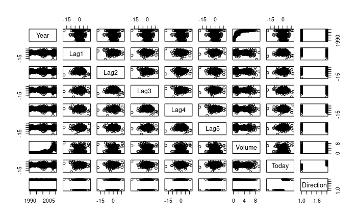

```r
pairs(Weekly)
```

2. Use the full data set to perform a logistic regression with Direction as the response and the five lag variables plus Volume as predictors. Use the summary function to print the results. Do any of the predictors appear to be statistically significant? If so, which ones?

```r
A=glm(Direction~Lag1+Lag2+Lag3+Lag4+Lag5+Volume, data=Weekly, family=binomial)
summary(A)
```

```
Call:
glm(formula = Direction ~ Lag1 + Lag2 + Lag3 + Lag4 + Lag5 +
    Volume, family = binomial, data = Weekly)

Deviance Residuals:
    Min       1Q   Median       3Q      Max
-1.6949  -1.2565   0.9913   1.0849   1.4579

Coefficients:
            Estimate Std. Error z value Pr(>|z|)
(Intercept)  0.26686    0.08593   3.106   0.0019 **
Lag1        -0.04127    0.02641  -1.563   0.1181
Lag2         0.05844    0.02686   2.175   0.0296 *
Lag3        -0.01606    0.02666  -0.602   0.5469
Lag4        -0.02779    0.02646  -1.050   0.2937
Lag5        -0.01447    0.02638  -0.549   0.5833
Volume      -0.02274    0.03690  -0.616   0.5377
---
Signif. codes:  0 ‘***’ 0.001 ‘**’ 0.01 ‘*’ 0.05 ‘.’ 0.1 ‘ ’ 1

(Dispersion parameter for binomial family taken to be 1)

    Null deviance: 1496.2  on 1088  degrees of freedom
Residual deviance: 1486.4  on 1082  degrees of freedom
AIC: 1500.4

Number of Fisher Scoring iterations: 4
```

It appears only Lag2 to be statistically significant.

3. Compute the confusion matrix and overall fraction of correct predictions. Explain what the confusion matrix is telling you about the types of mistakes made by logistic regression.

```r
A.Prob=predict(A,type='response')
contrasts(Direction)
```

```
     Up
Down  0
Up    1
```

```r
A.pred =rep (" Down ", 1089)
A.pred[A.Prob>.5] = "Up"
table(A.pred, Direction)
```

```
        Direction
A.pred   Down  Up
   Down    54  48
  Up      430 557
```

```r
mean(A.pred!=Direction)
```

```
[1] 0.4885216
```

4. Now fit the logistic regression model using a training data period from 1990 to 2008, with Lag2 as the only predictor. Compute the confusion matrix and the overall fraction of correct predictions for the held out data (that is, the data from 2009 and 2010).

```r
#Separation of training and test data
train <- (Year < 2009)
Weekly.Test=Weekly[!train,]
Direction.Test=Direction[!train]
```

```r
#Fitting of the model
B=glm(Direction~Lag2, data=Weekly, family=binomial, subset=train)
summary(B)
```

```
Call:
glm(formula = Direction ~ Lag2, family = binomial, data = Weekly,
    subset = train)

Deviance Residuals:
   Min      1Q  Median      3Q     Max
-1.536  -1.264   1.021   1.091   1.368

Coefficients:
            Estimate Std. Error z value Pr(>|z|)
(Intercept)  0.20326    0.06428   3.162  0.00157 **
Lag2         0.05810    0.02870   2.024  0.04298 *
---
Signif. codes:  0 ‘***’ 0.001 ‘**’ 0.01 ‘*’ 0.05 ‘.’ 0.1 ‘ ’ 1

(Dispersion parameter for binomial family taken to be 1)

    Null deviance: 1354.7  on 984  degrees of freedom
Residual deviance: 1350.5  on 983  degrees of freedom
AIC: 1354.5

Number of Fisher Scoring iterations: 4
```

```r
#Prediction and confusion matrix
B.Prob=predict(B, Weekly.Test, type='response')
B.pred =rep ("Down", length(Direction.Test))
B.pred[B.Prob>.5] = "Up"
table(B.pred, Direction.Test)
```

```
      Direction.Test
B.pred Down Up
  Down    9  5
  Up     34 56
```

```r
mean(B.pred!=Direction.Test)
```

```
[1] 0.375
```

5. Repeat (d) using LDA.

```r
library(MASS)
```

```r
#Fitting of the LDA model
LDA=lda(Direction~Lag2, data=Weekly, subset=train)
```

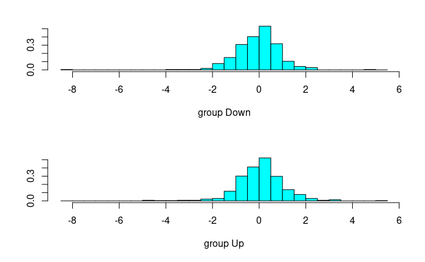

```r
plot(LDA)
```

```r
#Prediction and confusion matrix
LDA.pred=predict(LDA, Weekly.Test)
names(LDA.pred)
```

```
[1] "class"     "posterior" "x"
```

```r
LDA.Direction=LDA.pred$class
table(LDA.Direction, Direction.Test)
```

```
             Direction.Test
LDA.Direction Down Up
         Down    9  5
         Up     34 56
```

```r
mean(LDA.Direction!=Direction.Test)
```

```
[1] 0.375
```

6. Repeat (d) using QDA.

```r
#Fitting of the QDA model
QDA=qda(Direction~Lag2, data=Weekly, subset=train)
```

```r
#Prediction and confusion matrix
QDA.pred=predict(QDA, Weekly.Test)
names(QDA.pred)
```

```
[1] "class"     "posterior"
```

```r
QDA.Direction=QDA.pred$class
table(QDA.Direction, Direction.Test)
```

```
             Direction.Test
QDA.Direction Down Up
         Down    0  0
         Up     43 61
```

```r
mean(QDA.Direction!=Direction.Test)
```

```
[1] 0.4134615
```

7. Repeat (d) using KNN with K = 1.

```r
library(class)
```

```r
#Prediction and confusion matrix
train.X = as.matrix(Lag2[train])
test.X=as.matrix(Lag2[!train])
train.Direction=Direction[train]
set.seed(1)
KNN.pred=knn(train.X, test.X, train.Direction, k=1)
table(KNN.pred, Direction.Test)
```

```
        Direction.Test
KNN.pred Down Up
    Down   21 30
    Up     22 31
```

```r
mean(KNN.pred!=Direction.Test)
```

```
[1] 0.5
```

8. Repeat (d) using naive Bayes.

```r
library(e1071)
```

```r
#Fitting of the Naive Bayes model
NB=naiveBayes(Direction~Lag2, data=Weekly, subset=train)
NB
```

```
Naive Bayes Classifier for Discrete Predictors

Call:
naiveBayes.default(x = X, y = Y, laplace = laplace)

A-priori probabilities:
Y
     Down        Up
0.4477157 0.5522843

Conditional probabilities:
      Lag2
Y             [,1]     [,2]
  Down -0.03568254 2.199504
  Up    0.26036581 2.317485
```

```r
#Prediction and confusion matrix
NB.pred=predict(NB, Weekly.Test)
table(NB.pred, Direction.Test)
```

```
       Direction.Test
NB.pred Down Up
   Down    0  0
   Up     43 61
```

```r
mean(NB.pred==Direction.Test)
```

```
[1] 0.5865385
```

```r
mean(NB.pred!=Direction.Test)
```

```
[1] 0.4134615
```

1. Which of these methods appears to provide the best results on this data?

Best results are providen by logitic regression and LDA. Then, QDA and Naive Bayes. At last, KNN (K=1).

10. Experiment with different combinations of predictors, including possible transformations and interactions, for each of the methods. Report the variables, method, and associated confusion matrix that appears to provide the best results on the held out data. Note that you should also experiment with values for K in the KNN classifier.

```r
#Separation of training and test data
#train=(Year<2009)
#Weekly.Test=Weekly[!train,]#datos con train false, ie. year>=2009
#Direction.Test=Direction[!train]
#LDA=lda(Direction~Lag2, data=Weekly, subset=train)
#LDA.pred=predict(LDA, Weekly.Test)
#names(LDA.pred)
#LDA.Direction=LDA.pred$class
#table(LDA.Direction, Direction.Test)
#mean(LDA.Direction!=Direction.Test)
for (i in 2:8){
  Model=lda(Direction~Weekly[,i], data=Weekly, subset=train)
  LDA.pred=predict(Model, Weekly.Test)
  LDA.Direction=LDA.pred$class
  #print(table(LDA.Direction, Direction.Test))
  #print(mean(LDA.Direction!=Direction.Test))
}
```

```r
Model=lda(Direction~Lag2, data=Weekly, subset=train)
LDA.pred=predict(Model, Weekly.Test)
LDA.Direction=LDA.pred$class
table(LDA.Direction, Direction.Test)
```

```
             Direction.Test
LDA.Direction Down Up
         Down    9  5
         Up     34 56
```

```r
mean(LDA.Direction!=Direction.Test)
```

```
[1] 0.375
```

```r
cor(Weekly[-9])
```

```
              Year         Lag1        Lag2        Lag3         Lag4         Lag5      Volume        Today
Year    1.00000000 -0.032289274 -0.03339001 -0.03000649 -0.031127923 -0.030519101  0.84194162 -0.032459894
Lag1   -0.03228927  1.000000000 -0.07485305  0.05863568 -0.071273876 -0.008183096 -0.06495131 -0.075031842
Lag2   -0.03339001 -0.074853051  1.00000000 -0.07572091  0.058381535 -0.072499482 -0.08551314  0.059166717
Lag3   -0.03000649  0.058635682 -0.07572091  1.00000000 -0.075395865  0.060657175 -0.06928771 -0.071243639
Lag4   -0.03112792 -0.071273876  0.05838153 -0.07539587  1.000000000 -0.075675027 -0.06107462 -0.007825873
Lag5   -0.03051910 -0.008183096 -0.07249948  0.06065717 -0.075675027  1.000000000 -0.05851741  0.011012698
Volume  0.84194162 -0.064951313 -0.08551314 -0.06928771 -0.061074617 -0.058517414  1.00000000 -0.033077783
Today  -0.03245989 -0.075031842  0.05916672 -0.07124364 -0.007825873  0.011012698 -0.03307778  1.000000000
```

At last, we model KNN with different values for k in 1,…,100. We print only the best results, i.e., those that mean is greater than 0.6.

```r
train.X = as.matrix(Lag2[train])
test.X=as.matrix(Lag2[!train])
train.Direction=Direction[train]
set.seed(1)
for (i in 1:100){
  KNN.pred=knn(train.X, test.X, train.Direction, k=i)
  table(KNN.pred, Direction.Test)
  if (mean(KNN.pred==Direction.Test)>=0.6){
    print(i)
    print(mean(KNN.pred==Direction.Test))
  }
}
```

```
[1] 12
[1] 0.6057692
[1] 47
[1] 0.6153846
[1] 61
[1] 0.6057692
[1] 72
[1] 0.6057692
[1] 82
[1] 0.6057692
[1] 96
[1] 0.6153846
```

# Chapter 5 - Exercise 7

In Sections 5.3.2 and 5.3.3, we saw that the cv.glm() function can be used in order to compute the LOOCV test error estimate. Alternatively, one could compute those quantities using just the glm() and predict.glm() functions, and a for loop. You will now take this approach in order to compute the LOOCV error for a simple logistic regression model on the Weekly data set. Recall that in the context of classification problems, the LOOCV error is given in (5.4).

1. Fit a logistic regression model that predicts Direction using Lag1 and Lag2 .

```r
LRM<-glm(Direction~Lag1+Lag2, data=Weekly, family=binomial)
summary(LRM)
```

```
Call:
glm(formula = Direction ~ Lag1 + Lag2, family = binomial, data = Weekly)

Deviance Residuals:
   Min      1Q  Median      3Q
-1.623  -1.261   1.001   1.083
   Max
 1.506

Coefficients:
            Estimate Std. Error
(Intercept)  0.22122    0.06147
Lag1        -0.03872    0.02622
Lag2         0.06025    0.02655
            z value Pr(>|z|)
(Intercept)   3.599 0.000319 ***
Lag1         -1.477 0.139672
Lag2          2.270 0.023232 *
---
Signif. codes:
  0 ‘***’ 0.001 ‘**’ 0.01 ‘*’ 0.05
  ‘.’ 0.1 ‘ ’ 1

(Dispersion parameter for binomial family taken to be 1)

    Null deviance: 1496.2  on 1088  degrees of freedom
Residual deviance: 1488.2  on 1086  degrees of freedom
AIC: 1494.2

Number of Fisher Scoring iterations: 4
```

2. Fit a logistic regression model that predicts Direction using Lag1 and Lag2 using all but the first observation.

```r
LRMwo1<-glm(Direction~Lag1+Lag2, data=Weekly[-1,], family=binomial)
summary(LRMwo1)
```

```
Call:
glm(formula = Direction ~ Lag1 + Lag2, family = binomial, data = Weekly[-1,
    ])

Deviance Residuals:
    Min       1Q   Median       3Q      Max
-1.6258  -1.2617   0.9999   1.0819   1.5071

Coefficients:
            Estimate Std. Error z value Pr(>|z|)
(Intercept)  0.22324    0.06150   3.630 0.000283 ***
Lag1        -0.03843    0.02622  -1.466 0.142683
Lag2         0.06085    0.02656   2.291 0.021971 *
---
Signif. codes:  0 ‘***’ 0.001 ‘**’ 0.01 ‘*’ 0.05 ‘.’ 0.1 ‘ ’ 1

(Dispersion parameter for binomial family taken to be 1)

    Null deviance: 1494.6  on 1087  degrees of freedom
Residual deviance: 1486.5  on 1085  degrees of freedom
AIC: 1492.5

Number of Fisher Scoring iterations: 4
```

3. Use the model from (b) to predict the direction of the first observation. You can do this by predicting that the first observation will go up if P ( Direction = “Up” | Lag1 , Lag2 ) > 0.5. Was this observation correctly classified?

```r
X1pred<-if(predict ( LRMwo1 , Weekly[1,] , type = "response")>0.5){"Up"}else{"Down"}
X1pred==Weekly[1,]$Direction
```

```
[1] FALSE
```

4. Write a for loop from i = 1 to i = n, where n is the number of observations in the data set, that performs each of the following steps:
1. Fit a logistic regression model using all but the ith observation to predict Direction using Lag1 and Lag2.
2. Compute the posterior probability of the market moving up for the ith observation.
3. Use the posterior probability for the ith observation in order to predict whether or not the market moves up.
4. Determine whether or not an error was made in predicting the direction for the ith observation. If an error was made, then indicate this as a 1, and otherwise indicate it as a 0.

```r
n=dim(Weekly)[1]
cv.error=rep(0,n)
for (i in 1:n){
  LRMwoi<-glm(Direction~Lag1+Lag2, data=Weekly[-i,], family=binomial)
  Xipred<-if(predict ( LRMwoi , Weekly[i,] , type = "response")>0.5){"Up"}else{"Down"}
  cv.error[i]<- if (Xipred!=Weekly[i,]$Direction){1}else{0}
}
```

5. Take the average of the n numbers obtained in (d)iv in order to obtain the LOOCV estimate for the test error. Comment on the results.

```r
mean(cv.error)
```

```
[1] 0.4499541
```